# Final Project: R Reference

# R Reference Guide

## Loading Data and Packages

### library() and require()

The library() and require() functions are used to load add-on packages or data sets.

- Either function can be used for this, but the library() function will return an error if the requested package does not exist.

Here are examples of the library() and require() function:

```r
## Load "palmerpenguins" package with library()
library(palmerpenguins)
## Load "here" package with library()
library(here)
## Load "palmerpenguins" package with require()
require(palmerpenguins)
## Load "here" package with require()
require(here)
```

### here() and read.csv()

The read.csv() function reads a csv file in table format and creates a data frame from it.

The function here() finds your project’s files based on the current working directory when the “here” package was loaded.

Here are examples of read.csv() to create a data frame, and here() to find the data frame’s location:

```r
## Creating a data frame called "ginkgo_data" using read.csv()
ginkgo_data = read.csv(here("data", "ginkgo_data_2021.csv"))
## Creating a data frame called "ginkgo" using data.frame()
ginkgo = data.frame(ginkgo_data)

## Load "here" package with require()
require(here)
## Display location of "ginkgo" with here()
here("ginkgo")
```

```
## [1] "/Users/joshuaward/Documents/environmental_data/ginkgo"
```

## Data Structures

### c()

The function c() combines or concatenates its arguments into a vector (a 1-dimensional data structure consisting of 1 or more elements).

- All of the elements must be of the same type.
  - I can’t combine character and numeric types in the same call to c()

Here’s two examples using numeric and character data types:

```r
## Create a vector of numbers:
num_vec  = c(1, 4, 8, 9, 13)

## Create a vector of characters:
char_vec = c("a", "fish", "data is cool")
```

I can show the contents of a vector by typing the name of the vector, or using the print() function.

```r
## Typing the name of the vector into the console prints the contents
num_vec
```

```
## [1]  1  4  8  9 13
```

```r
## The print() function accomplishes the same task:
print(char_vec)
```

```
## [1] "a"            "fish"         "data is cool"
```

### length()

The length() function returns the length of R objects such as vectors, lists, or strings.

Here’s an examples of the length function using a vector:

```r
## Create a vector of numbers:
x <- c(42, 18, 24, 54, 63, 15, 10)
## Returns the number of variables in vector x
length(x)
```

```
## [1] 7
```

### matrix()

The matrix() function is used to create a matrix; R objects in which the elements are arranged in a two-dimensional rectangular layout with columns and rows.

Here’s an examples of the matrix function:

```r
## Create a matrix:
M = matrix(c(2,4,6,8,10,12,14,16,18,20,22,24), #data
           nrow=3, #number of rows
           ncol=4, #number of columns
           byrow=TRUE) #fill matrix by rows
## Print the matrix:
print(M)
```

```
##      [,1] [,2] [,3] [,4]
## [1,]    2    4    6    8
## [2,]   10   12   14   16
## [3,]   18   20   22   24
```

### data.frame()

The data.frame() function is used for storing data as a data frame or table.

- A data frame shares many similarities to matrices and lists.

Here’s an examples of creating a data frame from a csv called “ginkgo_data_2021.csv”:

```r
## Creating a data frame called "ginkgo_data" using read.csv()
ginkgo_data = read.csv(here("data", "ginkgo_data_2021.csv"))
## Creating a data frame called "ginkgo" using data.frame()
ginkgo = data.frame(ginkgo_data)
```

### nrow()

The nrow() function returns the number of rows present in a matrix or data frame.

Here’s an examples of the nrow() function with data frame “ginkgo”:

```r
## Return the number of rows in "ginkgo":
nrow(ginkgo)
```

```
## [1] 756
```

### ncol()

The ncol() function returns the number of columns present in a matrix or data frame.

Here’s an examples of the ncol() function with data frame “ginkgo”:

```r
## Return the number of columns in "ginkgo":
ncol(ginkgo)
```

```
## [1] 6
```

### dim()

The dim() function returns the dimensions (rows and columns) present in a matrix or data frame.

Here’s an examples of the dim() function with data frame “ginkgo”:

```r
## Return the dimensions of "ginkgo":
dim(ginkgo)
```

```
## [1] 756   6
```

## Subsetting

### $

The $ operator is used to extract or subset a specific part of a matrix or data frame.

Here’s an examples of using the $ operator to extract values in a column of data frame “ginkgo”:

```r
## Extract values in column "petiole_length":
ginkgo$petiole_length
```

```
##   [1]  30.00  23.00  20.00  28.00  25.00  55.00  27.00  20.00  50.00  23.00
##  [11]  28.00  26.00  43.00  45.00  42.00  40.00  42.00  40.00  48.00  37.00
##  [21]  50.00  35.00  47.00  23.00  21.00  25.00  41.00  78.00  88.00  38.00
##  [31]  59.00  85.00  42.00  73.00  56.00  76.00  94.00  57.00  30.00  28.00
##  [41]  80.00  58.00  70.00  64.00  43.00  58.00  49.00  35.00  72.00  88.00
##  [51]  63.00  55.00  56.00  54.00  49.00  28.00  57.00  53.00  51.00  80.00
##  [61]  42.00  49.00  49.00  36.00  33.00  46.00  59.00  41.00  58.00  96.00
##  [71]  58.00  45.00  34.00  35.00  59.00  78.00  78.00  41.00  75.00  41.00
##  [81]  30.00  23.00  20.00  28.00  25.00  55.00  27.00  20.00  50.00  23.00
##  [91]  28.00  26.00  43.00  45.00  42.00  40.00  42.00  40.00  48.00  37.00
## [101]  50.00  35.00  47.00  23.00  21.00  25.00  41.00  57.00  40.00  25.00
## [111]  38.00  48.00  48.00  53.00  52.00  52.00  51.00  65.00  48.00  88.00
## [121]  25.00  33.00  68.00  45.00  55.00  51.00  61.00  30.00  37.00  50.00
## [131]  72.00  31.00  54.00  27.00  32.00  59.00  48.00  54.00  93.00  54.00
## [141]  43.00  42.00  14.00  27.00  70.00  58.00  48.00  60.00  52.00  55.00
```

[output cut: 61 more lines]

### [ ]

The [ ] operator is used to extract specific elements from a matrix or data frame.

Here are some examples of using the [ ] operator to extract various elements from data frame “ginkgo”:

```r
## Extract the first row of "ginkgo":
ginkgo[1, ]
```

```
##   site_id seeds_present max_width max_depth notch_depth petiole_length
## 1    7719         FALSE        71        40           0             30
```

```r
## Extract the element in row 2, column 3 of "ginkgo":
ginkgo[2,3]
```

```
## [1] 64
```

```r
## Extract the third column of "ginkgo":
ginkgo[ ,3]
```

```
##   [1]  71.0  64.0  55.0  62.0  65.0  70.0  63.0  56.0  51.0  57.0  59.0  63.0
##  [13]  70.0  50.0  56.0  46.0  54.0  62.0  56.0  55.0  59.0  60.0  63.0  61.0
##  [25]  58.0  55.0  53.0  81.0  94.0  75.0  82.0  86.0  79.0  93.0  88.0  76.0
##  [37]  71.0  91.0  71.0  82.0  65.0  83.0  73.0 102.0  78.0  88.0  81.0  70.0
##  [49]  80.0  96.0  80.0  82.0  86.0  87.0  89.0  69.0  93.0  98.0  81.0  79.0
##  [61]  82.0  85.0  81.0  59.0  53.0  83.0  80.0  77.0  81.0  76.0  82.0  81.0
##  [73]  77.0  68.0  41.0  70.0  68.0  80.0  89.0  90.0  71.0  64.0  55.0  62.0
##  [85]  65.0  70.0  63.0  56.0  51.0  57.0  59.0  63.0  70.0  50.0  56.0  46.0
##  [97]  54.0  62.0  56.0  55.0  59.0  60.0  63.0  61.0  58.0  55.0  53.0  77.0
## [109]  72.0  57.0  75.0  75.0  75.0  67.0  74.0  71.0  72.0  55.0  77.0  97.0
## [121]  73.0  64.0  69.0  92.0  64.0  68.0  53.0  97.0 100.0  90.0  89.0  59.0
## [133]  97.0  76.0  85.0  90.0  87.0  85.0  80.0  86.0  89.0  84.0  88.0  80.0
## [145] 102.0  94.0  95.0 109.0  84.0  68.0  59.0  74.0  70.0  71.0  69.0  74.0
## [157]  70.0  78.0  87.0  69.0  60.0  72.0  59.0  75.0  81.0  82.0  74.0  72.0
## [169]  79.0  84.0  75.0  72.0  88.0  80.0  90.0  58.0  61.0  95.0  72.0  90.0
```

[output cut: 48 more lines]

### subset()

The subset() function return subsets of vectors, matrices or data frames.

Here’s an examples of using the subset() function to retrieve all the data for Adelie penguins in the species column of the “palmerpenguins” package dataset:

```r
## Return data for Adelie penguins with subset():
subset(penguins, species == "Adelie")
```

```
## # A tibble: 152 × 8
##    species island    bill_length_mm bill_depth_mm flipper_length_mm body_mass_g
##    <fct>   <fct>              <dbl>         <dbl>             <int>       <int>
##  1 Adelie  Torgersen           39.1          18.7               181        3750
##  2 Adelie  Torgersen           39.5          17.4               186        3800
##  3 Adelie  Torgersen           40.3          18                 195        3250
##  4 Adelie  Torgersen           NA            NA                  NA          NA
##  5 Adelie  Torgersen           36.7          19.3               193        3450
##  6 Adelie  Torgersen           39.3          20.6               190        3650
##  7 Adelie  Torgersen           38.9          17.8               181        3625
##  8 Adelie  Torgersen           39.2          19.6               195        4675
##  9 Adelie  Torgersen           34.1          18.1               193        3475
## 10 Adelie  Torgersen           42            20.2               190        4250
## # … with 142 more rows, and 2 more variables: sex <fct>, year <int>
```

## Numerical Data Exploration

### summary()

The summary() function computes summary statistics of a data set.

Here’s an examples of the summary() function with data frame “ginkgo”:

```r
## Produce a summary of "ginkgo":
summary(ginkgo)
```

```
##     site_id      seeds_present     max_width        max_depth
##  Min.   : 1896   Mode :logical   Min.   : 16.00   Min.   : 19.00
##  1st Qu.: 3703   FALSE:636       1st Qu.: 63.00   1st Qu.: 43.00
##  Median : 6066   TRUE :120       Median : 74.00   Median : 51.00
##  Mean   : 6079                   Mean   : 74.34   Mean   : 58.51
##  3rd Qu.: 7206                   3rd Qu.: 85.00   3rd Qu.: 66.00
##  Max.   :12982                   Max.   :130.00   Max.   :145.00
##
##   notch_depth    petiole_length
##  Min.   : 0.00   Min.   :  8.00
##  1st Qu.: 0.00   1st Qu.: 34.00
##  Median : 0.00   Median : 47.00
##  Mean   : 2.99   Mean   : 48.25
##  3rd Qu.: 4.00   3rd Qu.: 60.00
##  Max.   :49.00   Max.   :113.00
##                  NA's   :4
```

### mean()

The mean() function computes the arithmetic mean from the numerical values in a data set.

- In a matrix or data frame the column must be specified.

Here’s an examples of the mean() function for the “max_depth” column of data frame “ginkgo”:

```r
##Calculate the mean of "max_depth" from data frame "ginkgo":
mean(ginkgo$max_depth)
```

```
## [1] 58.51455
```

### sd()

The sd() function computes the standard deviation from the numerical values in a data set.

- In a matrix or data frame the column must be specified.

Here’s an examples of the sd() function for the “max_depth” column of data frame “ginkgo”:

```r
##Calculate the standard deviation of "max_depth" from data frame "ginkgo":
sd(ginkgo$max_depth)
```

```
## [1] 23.46108
```

## Graphical Data Exploration

### plot()

The plot() function is used to create a scatterplot.

- For a matrix or data frame you must specify the columns you wish to plot.

Creating a scatterplot of max leaf depth (x) and max leaf width (y) with data frame “ginkgo”:

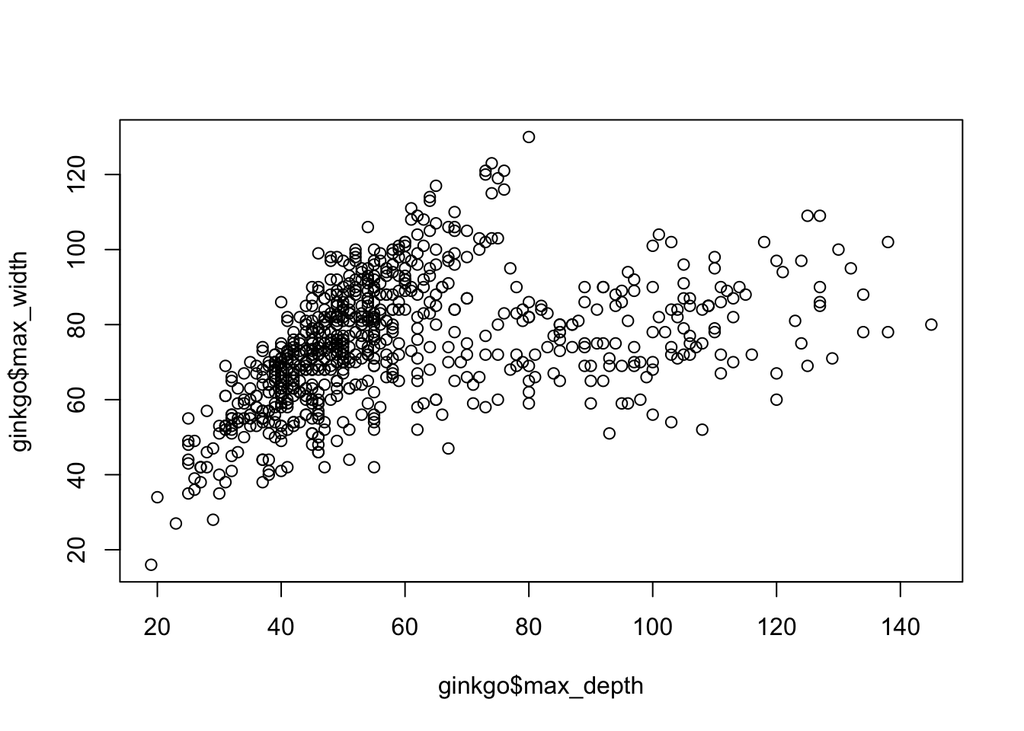

```r
##Create a scatterplot from data frame "ginkgo":
plot(ginkgo$max_depth, ginkgo$max_width)
```

#### col=

Use the col= argument to change the color of the points:

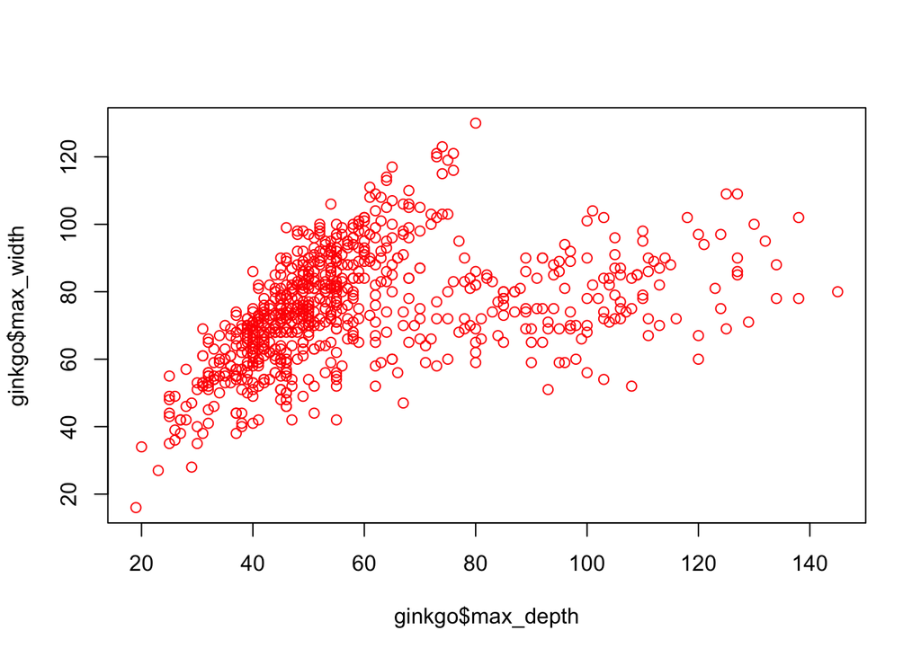

```r
# Make the points red:
plot(ginkgo$max_depth, ginkgo$max_width, col="red")
```

#### pch=

Use the pch= argument to change the point shapes depending on the “shape number”.

Some examples of “shape numbers”:

- pch = 2,triangle point up
- pch = 5,diamond
- pch = 10,circle plus
- pch = 18, filled diamond
- pch = 19, solid circle

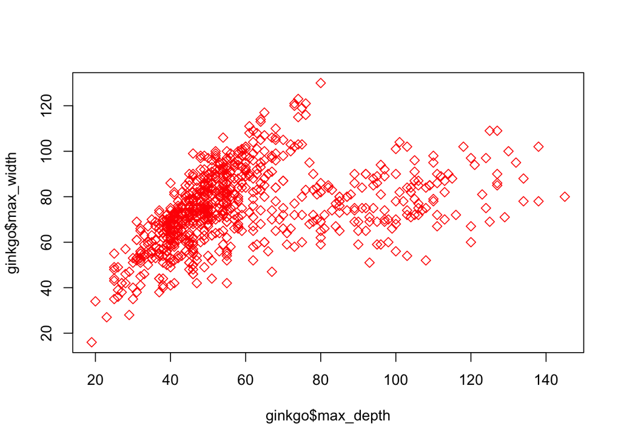

```r
# Make the points diamonds:
plot(ginkgo$max_depth, ginkgo$max_width, col="red", pch=5)
```

#### cex=

Use the cex= argument to change the size of the plotting text and symbols scaled relative to the default.

1=default, 1.5 is 50% larger, 0.5 is 50% smaller, etc.

- cex.axis = magnification of axis annotation relative to cex
- cex.lab = magnification of x and y labels relative to cex
- cex.main = magnification of titles relative to cex
- cex.sub = magnification of subtitles relative to cex

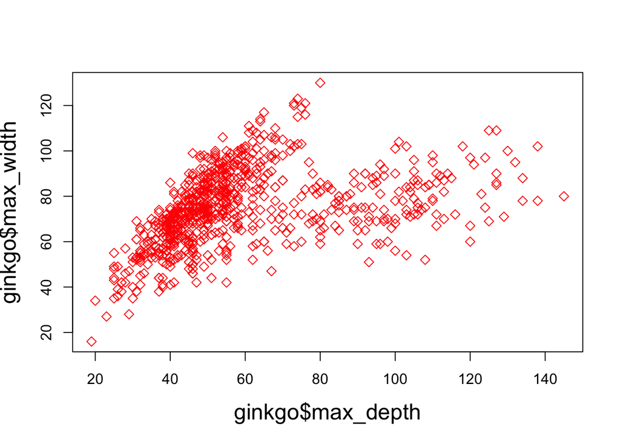

```r
# Make the x and y labels 50% larger:
plot(ginkgo$max_depth, ginkgo$max_width, col="red", pch=5, cex.lab=1.5)
```

#### main=

Use the main= argument to add text for the main title:

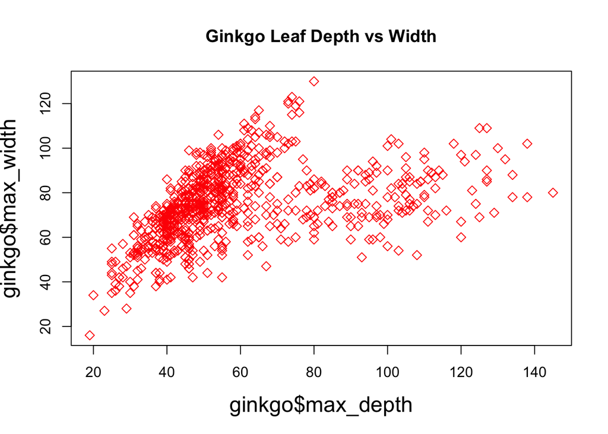

```r
# Add text for the main title:
plot(ginkgo$max_depth, ginkgo$max_width, col="red", pch=5, cex.lab=1.5, main= "Ginkgo Leaf Depth vs Width")
```

#### xlab=

Use the xlab = argument to label the x-axis:

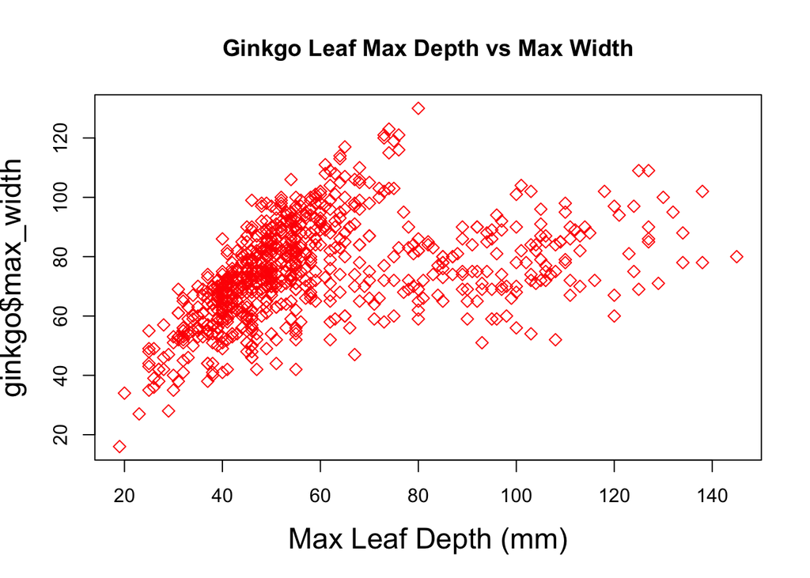

```r
#Label the x-axis:
plot(ginkgo$max_depth, ginkgo$max_width, col="red", pch=5, cex.lab=1.5, main= "Ginkgo Leaf Max Depth vs Max Width",
     xlab="Max Leaf Depth (mm)")
```

#### ylab=

Use the ylab = argument to label the y-axis:

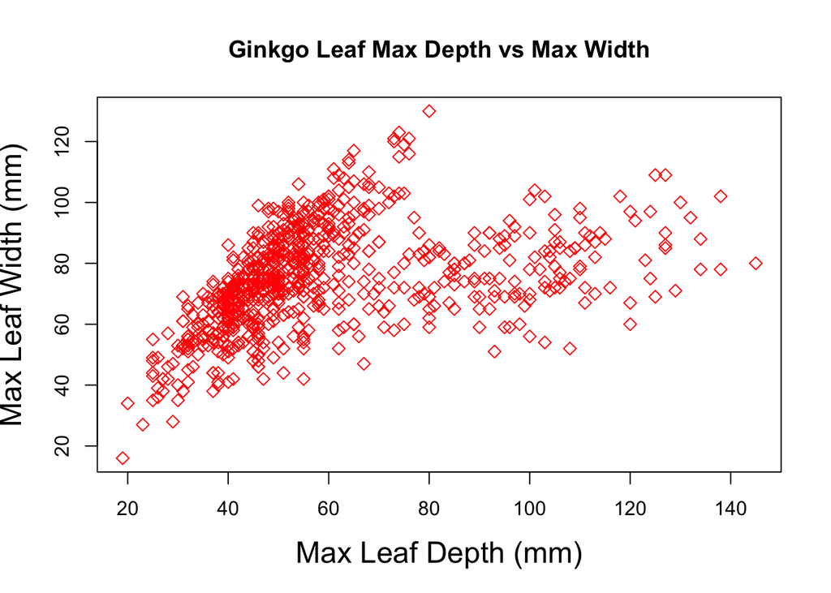

```r
#Label the y-axis:
plot(ginkgo$max_depth, ginkgo$max_width, col="red", pch=5, cex.lab=1.5, main= "Ginkgo Leaf Max Depth vs Max Width",
     xlab="Max Leaf Depth (mm)", ylab="Max Leaf Width (mm)")
```

#### xlim=

Use the xlim= argument to specify the upper and lower limits of the x-axis:

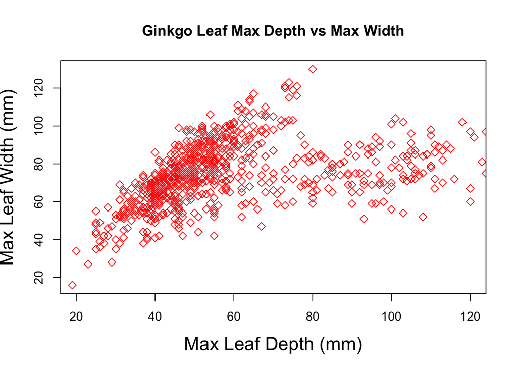

```r
# Upper and lower limits of the x-axis:
plot(ginkgo$max_depth, ginkgo$max_width, col="red", pch=5, cex.lab=1.5, main= "Ginkgo Leaf Max Depth vs Max Width",
     xlab="Max Leaf Depth (mm)", ylab="Max Leaf Width (mm)",xlim=c(20,120))
```

#### ylim=

Use the ylim= argument to specify the upper and lower limits of the y-axis:

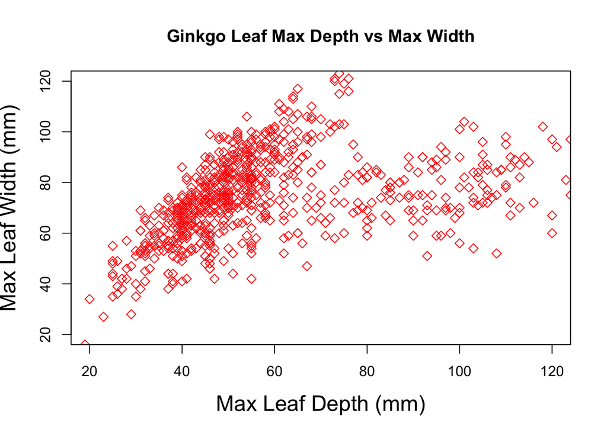

```r
# Upper and lower limits of the y-axis:
plot(ginkgo$max_depth, ginkgo$max_width, col="red", pch=5, cex.lab=1.5, main= "Ginkgo Leaf Max Depth vs Max Width",
     xlab="Max Leaf Depth (mm)", ylab="Max Leaf Width (mm)",xlim=c(20,120),ylim=c(20,120))
```

### hist()

The hist() function is used to create a histogram.

- For a matrix or data frame you must specify the column(s) you wish to plot.

Creating a histogram of penguin flipper length with data frame “palmerpenguins”:

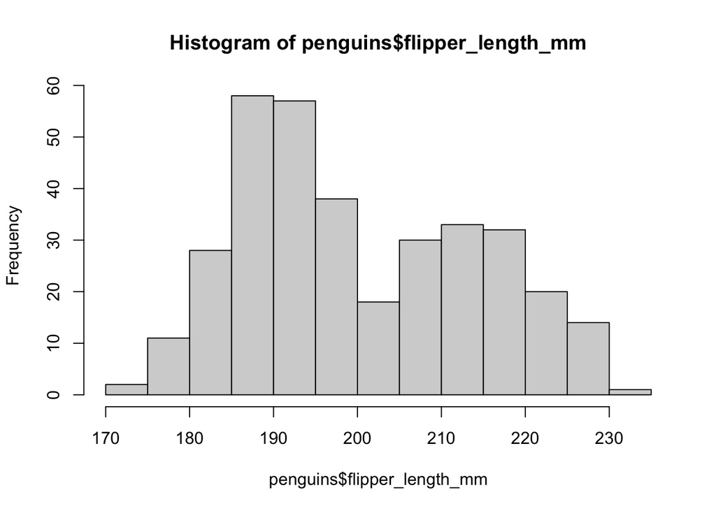

```r
##Create a histogram from data frame "palmerpenguins":
hist(penguins$flipper_length_mm)
```

#### breaks=

Use the breaks= argument to control the number of bars, cells or bins of the histogram:

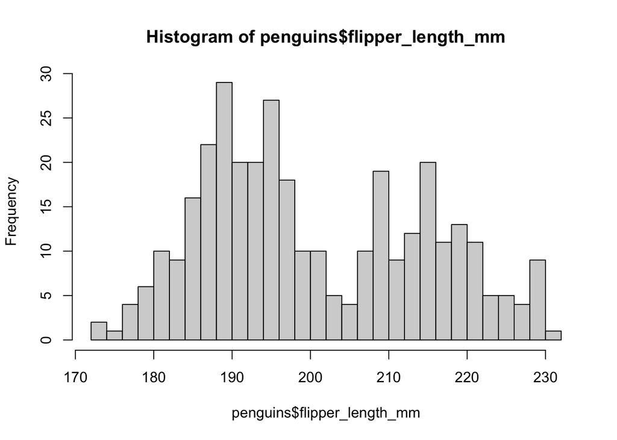

```r
## 30 breaks:
hist(penguins$flipper_length_mm, breaks=30)
```

### boxplot()

The boxplot() function is used to create a boxplot.

- For a matrix or data frame you must specify the column(s) you wish to plot.

Creating a boxplot of ginkgo petiole lengths from data frame “ginkgo”:

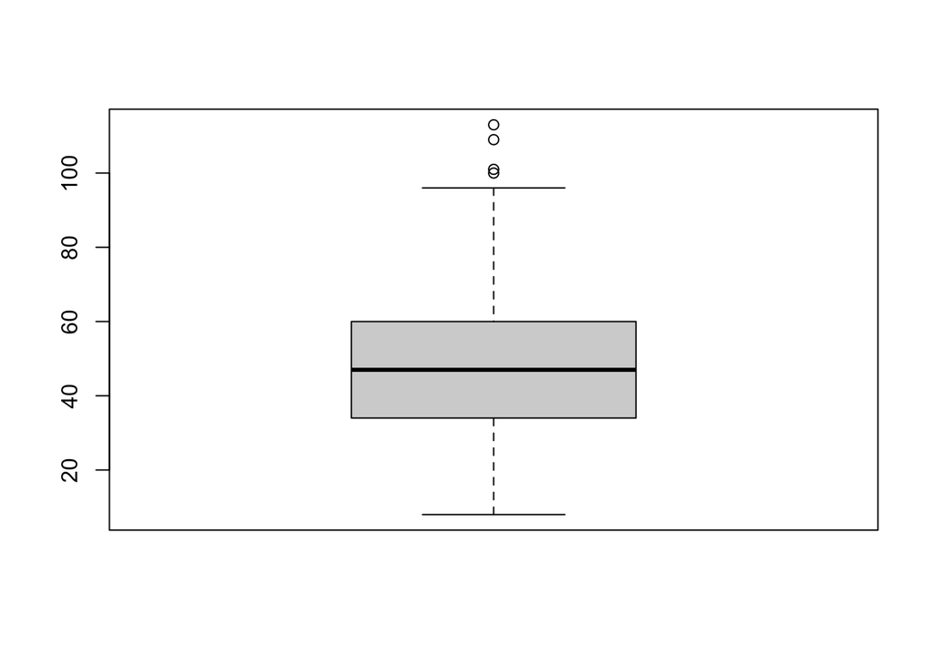

```r
##Create a boxplot of ginkgo petiole lengths:
boxplot(ginkgo$petiole_length)
```

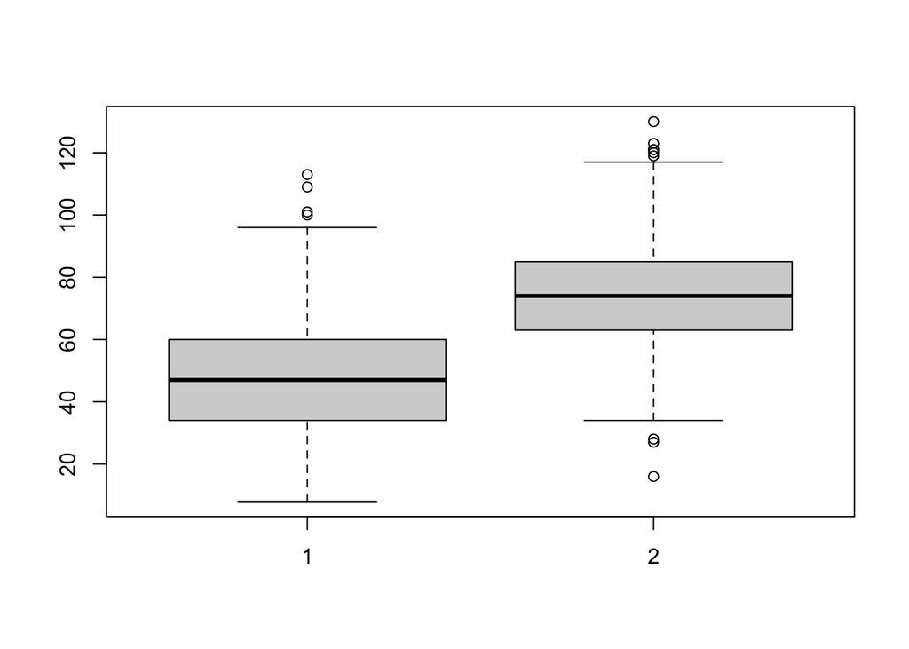

```r
##Create a conditional boxplot:
boxplot(ginkgo$petiole_length, ginkgo$max_width)
```

### par()

The par() function combines multiple plots into one overall graph.

Here’s an examples of the par() function with 4 plots arranged in 2 rows and 2 columns:

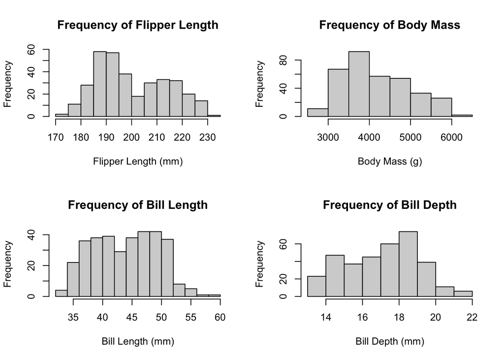

```r
# Creates a matrix of nrows x ncols:
par(mfrow=c(2,2))
# The 4 plots:
hist(penguins$flipper_length_mm, main= "Frequency of Flipper Length",
     xlab="Flipper Length (mm)", ylab="Frequency")

hist(penguins$body_mass_g, main= "Frequency of Body Mass",
     xlab="Body Mass (g)", ylab="Frequency")

hist(penguins$bill_length_mm, main= "Frequency of Bill Length",
     xlab="Bill Length (mm)", ylab="Frequency")

hist(penguins$bill_depth_mm, main= "Frequency of Bill Depth",
     xlab="Bill Depth (mm)", ylab="Frequency")
```

## Distribution Functions

### Normal Distribution

Distribution functions for normal distribution

```
dnorm(x, mean = 0, sd = 1, log = FALSE)

pnorm(q, mean = 0, sd = 1, lower.tail = TRUE, log.p = FALSE)

qnorm(p, mean = 0, sd = 1, lower.tail = TRUE, log.p = FALSE)
```

- x,q = vector of quantiles
- p = vector of probabilities

#### dnorm()

The dnorm() function gives the density of the normal distribution.

Here’s an examples of the density function:

```r
#dnorm
dnorm(4, mean = 2, sd = 1, log = FALSE)
```

```
## [1] 0.05399097
```

#### pnorm()

The pnorm() function gives the distribution of the normal distribution.

Here’s an examples of the distribution function:

```r
#pnorm
pnorm(7, mean = 2, sd = 3, lower.tail = TRUE, log.p = FALSE)
```

```
## [1] 0.9522096
```

#### qnorm()

The qnorm() function gives the quantile of the normal distribution.

Here’s an examples of the quantile function:

```r
#qnorm
qnorm(0.85, mean = 70, sd = 3, lower.tail = TRUE, log.p = FALSE)
```

```
## [1] 73.1093
```

### Binomial Distribution

Distribution functions for binomial distribution

```
dbinom(x, size, prob, log = FALSE)

pbinom(q, size, prob, lower.tail = TRUE, log.p = FALSE)

qbinom(p, size, prob, lower.tail = TRUE, log.p = FALSE)
```

- x,q = vector of quantiles
- p = vector of probabilities

#### dbinom()

The dbinom() function gives the density of the binomial distribution.

Here’s an examples of the density function:

```r
#dbinom
dbinom(3, size = 4, prob = 0.75, log = FALSE)
```

```
## [1] 0.421875
```

#### pbinom()

The binom() function gives the distribution of the binomial distribution.

Here’s an examples of the distribution function:

```r
#pbinom
pbinom(3, size=5, 0.75, lower.tail = TRUE, log.p = FALSE)
```

```
## [1] 0.3671875
```

#### qbinom()

The qbinom() function gives the quantile of the binomial distribution.

Here’s an examples of the quantile function:

```r
#qbinom
qbinom(p = 0.6, size = 7, prob = 0.8, lower.tail = TRUE, log.p = FALSE)
```

```
## [1] 6
```